# Assignment 6

## Try to submit as an HTML file

Print your name below

```python
print("Kenneth Lim")
```

```
Kenneth Lim
```

Import the "pandas" and "matplotlib.pyplot" library

```python
# Write your answer here:
import matplotlib.pyplot as plt
import pandas as pd
```

(a) Compute function for each individual (map)

- Import the datset "data/investment.csv"
- Write a lambda function for $V = P/(1+r)$.
- Use `list(map(...))` to calculate $V$ for each row of the dataset

```python
# Write your own code here
data_investment = pd.read_csv("data/investment.csv")
V = lambda P,r : P/(1+r)
list(map(V,data_investment["P"],data_investment["r"]))
```

```
[990.09900990099,
 1960.7843137254902,
 485.43689320388347,
 769.2307692307692,
 370.3703703703703]
```

(b) Convert to upper case

- Create the following function to convert a string to upper case

$\quad$ `fn_upper = lambda x: x.upper()`

- Create a new column, "countryname_upper"

that converts "countryname" to upper case.

```python
# Write your own code here
fn_upper = lambda x: x.upper()
wdi_2020_upper = pd.read_csv("data/wdi_2020.csv")
wdi_2020_upper["countryname_upper"]= wdi_2020_upper["countryname"].apply(fn_upper)
display(wdi_2020_upper)
```

[output not shown]

For questions (b)-(d), read "data/wdi_2020.csv"

(c) Extract sorted elements from a dataset

- Sort by "prop_urbanpopulation" in descending order
- Subset the 5 countries with the highest urban population

```python
# Write your code here
wdi_2020 = pd.read_csv("data/wdi_2020.csv")
wdi_2020_sorted = wdi_2020.sort_values(by=['prop_urbanpopulation'], ascending=False)
display(wdi_2020_sorted)

display(wdi_2020_sorted.iloc[0:5])
```

|  | year | yearcode | countryname | countrycode | prop_urbanpopulation |
| --- | --- | --- | --- | --- | --- |
| 212 | 2020 | YR2020 | Singapore | SGP | 100.000 |
| 147 | 2020 | YR2020 | Macao SAR, China | MAC | 100.000 |
| 40 | 2020 | YR2020 | Cayman Islands | CYM | 100.000 |
| 90 | 2020 | YR2020 | Gibraltar | GIB | 100.000 |
| 103 | 2020 | YR2020 | Hong Kong SAR, China | HKG | 100.000 |
| ... | ... | ... | ... | ... | ... |
| 34 | 2020 | YR2020 | Burundi | BDI | 13.708 |
| 191 | 2020 | YR2020 | Papua New Guinea | PNG | 13.345 |
| 127 | 2020 | YR2020 | Kosovo | XKX | NaN |
| 183 | 2020 | YR2020 | Not classified | INX | NaN |
| 227 | 2020 | YR2020 | St. Martin (French part) | MAF | NaN |

266 rows × 5 columns

|  | year | yearcode | countryname | countrycode | prop_urbanpopulation |
| --- | --- | --- | --- | --- | --- |
| 212 | 2020 | YR2020 | Singapore | SGP | 100.0 |
| 147 | 2020 | YR2020 | Macao SAR, China | MAC | 100.0 |
| 40 | 2020 | YR2020 | Cayman Islands | CYM | 100.0 |
| 90 | 2020 | YR2020 | Gibraltar | GIB | 100.0 |
| 103 | 2020 | YR2020 | Hong Kong SAR, China | HKG | 100.0 |

(d) Subset elements with query

- Compute the median of "prop_urbanpopulation"
- Use ".query()" to subset countries with

"prop_urbanpopulation" above the median

```python
# Write your own code here
median_value = wdi_2020_sorted['prop_urbanpopulation'].median()
print(median_value)
wdi_2020_above_median = wdi_2020_sorted.query("prop_urbanpopulation > @median_value")
display(wdi_2020_above_median)
```

```
60.69872843
```

|  | year | yearcode | countryname | countrycode | prop_urbanpopulation |
| --- | --- | --- | --- | --- | --- |
| 212 | 2020 | YR2020 | Singapore | SGP | 100.000000 |
| 147 | 2020 | YR2020 | Macao SAR, China | MAC | 100.000000 |
| 40 | 2020 | YR2020 | Cayman Islands | CYM | 100.000000 |
| 90 | 2020 | YR2020 | Gibraltar | GIB | 100.000000 |
| 103 | 2020 | YR2020 | Hong Kong SAR, China | HKG | 100.000000 |
| ... | ... | ... | ... | ... | ... |
| 3 | 2020 | YR2020 | Albania | ALB | 62.112000 |
| 84 | 2020 | YR2020 | French Polynesia | PYF | 61.975000 |
| 160 | 2020 | YR2020 | Middle East & North Africa (excluding high inc... | MNA | 61.892321 |
| 161 | 2020 | YR2020 | Middle East & North Africa (IDA & IBRD countries) | TMN | 61.717344 |
| 46 | 2020 | YR2020 | China | CHN | 61.428000 |

131 rows × 5 columns

(e) Plot by category

- Read "data/wdi_urban.csv"

This contains data from 1980 and 2020

- Create a list with the unique values of "year"
- Create a plot with a ...
  - Histogram of "prop_urbanpopulation"

  for each year
  - Set the histogram option `alpha = 0.5` for transparency
  - All the histograms should be overlapping
  - Create a legend with the list of years
  - Label the axes and the title

What do we learn from the graph?

HINT: See the example at the end of Lecture 10

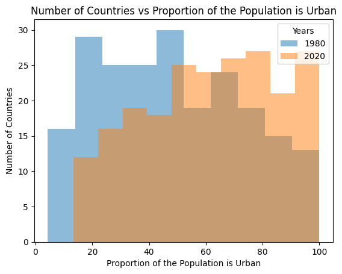

```python
# Write your own code here
wdi_urban = pd.read_csv("data/wdi_urban.csv")
list_unique_year = pd.unique(wdi_urban["year"])

for category in list_unique_year:
    df   = wdi_urban.query("year == @category")
    plt.hist(x = df["prop_urbanpopulation"], alpha = 0.5)
plt.xlabel("Proportion of the Population is Urban")
plt.ylabel("Number of Countries")
plt.title("Number of Countries vs Proportion of the Population is Urban")
plt.legend(labels = list_unique_year,
title = "Years")
plt.show()

# From this graph, we learn that as the years progressed, the proportion of the population that is urban increases. Indicated by the orange histograms(2020) being more towards the right end than the blue histograms(1980)
```